# Very Basic Introduction to C++ and R

### Add R functions and documentation

8. Here we will create three R files: `simulate_pop.R` which contains a wrapper for the simulation procedures, `est_rf` which contains a wrapper to the recombination fraction estimation procedure and `utils.R` which contains all function related to the simulation procedure and the wrapper to the C++ code which performs the real estimation of recombination fraction. Let us take a look into each one of these files [here](https://github.com/mmollina/rfpack/tree/master/R).

Most importantly, take a close look at the functions that use `.Call`. Here is an example:

```r
est_out<-function(geno, seg_type=NULL, nind)
{
  r<-.Call("est_rf_out",
           geno,
           as.numeric(seg_type),
           as.numeric(nind),
           options()$width-6,
           PACKAGE = "rfpack" )
  names(r)<-c("CC", "CR", "RC", "RR")
  for(i in 1:4) dimnames(r[[i]])<-list(colnames(geno), colnames(geno))
  return(r)
}
```

This is the syntax to call a C++ function inside R though Rcpp. The first argument is the name of the C++ function the following arguments are the ones into the C++ function and the last one is the name of the package. This function returns a R `list`. This is due to how we return the results in the [C++ code](https://github.com/mmollina/rfpack/blob/master/src/twopt_est_out.cpp).

```r
#' A Simulation function
#'
#' This function simulates experimental crosses: backcross, F2 and outcrossing populations.
#' @param type type of cross. Must be one of the following: "bc" fro backcross, "f2" for f2 and "out" fro outcross.
#' @param n.ind number of individuals
#' @param n.mrk number of markers
#' @param ch.len length of chromosome in centimorgans
#' @param missing percentage of missing data
#' @param n.ch number of chromosomes
#' @param dom43 if \code{type=="f2"}, percentage of dominant markers NOT BB, BB
#' @param dom51 if \code{type=="f2"}, percentage of dominant markers NOT AA, AA
#' @param prob if \code{type=="out"}, probability of markers types A, B1, B2, B3, C, D1 and D2
#' @param verbose logical. If \code{TRUE}, prints the progress of the simulation per chromosome.
#' @export
#' @examples
#' dat<-simulate_pop(type="f2", n.ind = 250,
#'                   n.mrk = 1000, ch.len = 200,
#'                   missing = 15, dom43 = 20,
#'                   dom51 = 20, n.ch = 2,
#'                   verbose = TRUE)
#' require(onemap)
#' dat
```

### Compiling documentation

10. In Rstudio, in the `Build` tab, click in `more` and then in `Document`
11. Manually, create `rfpack-internal.Rd` file containing the with the internal that should not be directly called by the user:

```r
\name{rfpack-internal}
\alias{check.type}
\alias{est_bc}
\alias{est_f2}
\alias{est_out}
\alias{imf.k}
\alias{mf.k}
\alias{sim.gam}
\alias{sim.pop.bc}
\alias{sim.pop.f2}
\alias{sim.pop.out}

\title{Internal rfpack functions}
\description{
  Functions from \pkg{rfpack} not to be directly called by the user.
}
\usage{
est_out(geno, seg_type=NULL, nind)
est_f2(geno, seg_type=NULL, nind)
est_bc(geno, nind)
mf.k (d)
imf.k (r)
sim.gam(n.mrk, r, init=0)
sim.pop.bc(n.ind, n.mrk, ch.len, missing=0, n.ch=1, verbose=TRUE)
check.type(x)
sim.pop.f2(n.ind, n.mrk, ch.len, dom43=0, dom51=0, missing=0, n.ch=1, verbose=TRUE)
sim.pop.out(n.ind, n.mrk, ch.len, missing=0, prob=c(1,1,1,1,1,1,1), n.ch=1, verbose=TRUE)
}
\author{Marcelo Mollinari}
\keyword{internal}
```

### Checking and building the package

12. In order to Rcpp finds the shared libraries, we need to modify the NAMESPACE file. If `roxygen2` created a NAMESPACE file, you should delete first comment line and add the following lines:

```
useDynLib(rfpack)
exportPattern("^[[:alpha:]]+")
importFrom(Rcpp, evalCpp)
```

13. Now, click in `check`. Rstudio will use `devtools` to make all checks in our package. This automatically compile the documentation and check for all sorts of errors, warnings and notes. Probably we will get some of them, it is normal at the first time. If you want to submit your package to `CRAN`, all steps shoud pass trough the check procedure marked with OK! It can take some time to figure out some of the errors. But again, it is completely normal, just take your time and lots of research on internet and you will fix the errors. Since your package was checked, you can click in `Build & Reload` button and use it!
14. So, let us use our package!

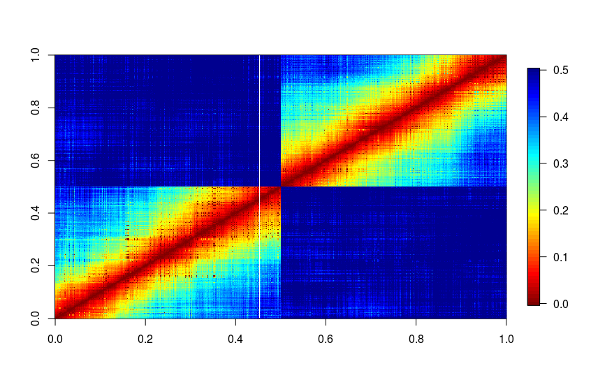

```r
require(rfpack)
?simulate_pop
dat<-simulate_pop(type="f2", n.ind = 250,
                   n.mrk = 1000, ch.len = 200,
                   dom43 = 20, dom51 = 20,
                   missing = 15, n.ch = 2,
                   verbose = TRUE)
require(onemap)
dat
system.time(r<-est_rf(dat))
round(r[1:10, 1:10],3)

require(fields)
image.plot(as.matrix(as.dist(r, upper=TRUE, diag=TRUE)), col=rev(tim.colors()))
```